# Large scale text analysis with deep learning

**6. Pooling слои продвинутые (3 балла)**

Pooling слои дают прекрасные результаты, одни из лучших на валидационных данных. А Attentive pooling еще и показывает великолепные результаты на train data.

```python
from scipy.special import softmax

def SoftmaxPool(v):
  m = softmax(v)
  # print(m.shape)
  # print(m.sum(axis=2).shape)
  return m.sum(axis=2)
```

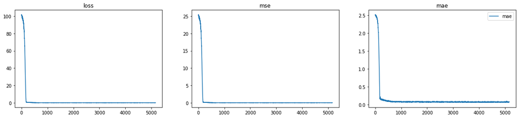

```
Train Loss: 0.15751582384109497
Train Mean square error: 0.03938
Train Mean absolute error: 0.09812
val results:
Mean square error: 0.03933
Mean absolute error: 0.07706
```

```python
class SalaryPredictorSoftmax(nn.Module):
    def __init__(self, n_tokens=len(tokens), n_cat_features=len(categorical_vectorizer.vocabulary_), hid_size=8):
        super().__init__()
        self.embedder = nn.Embedding(n_tokens, hid_size)
        self.title_encoder = nn.Sequential(
            nn.Conv1d(hid_size, hid_size, kernel_size=2),
            nn.BatchNorm1d(hid_size),
            nn.Dropout(p=0.25),
            nn.ReLU()
        )
        self.description_encoder = nn.Sequential(
            nn.Conv1d(hid_size, hid_size, kernel_size=2),
            nn.BatchNorm1d(hid_size),
            nn.Dropout(p=0.25),
            nn.ReLU()
        )
        self.maxpool = nn.AdaptiveMaxPool1d(output_size=1)
        self.categorical_encoder = nn.Sequential(
            nn.Linear(n_cat_features, hid_size * 2),
            nn.ReLU(),
            nn.Linear(hid_size * 2, hid_size * 2),
            nn.ReLU()
        )
        self.prefinal_predictor = nn.Sequential(
            nn.Linear(hid_size * 4, hid_size),
            nn.ReLU()
        )
        self.final_predictor = nn.Sequential(
            nn.Linear(hid_size, 1)
        )


    def forward(self, batch):

        title_embeddings = self.embedder(batch['Title']).permute(0, 2, 1)
        title_features = self.title_encoder(title_embeddings).squeeze().detach().cpu().numpy()

        title_features  = SoftmaxPool(title_features)
        title_features = torch.from_numpy(title_features).cuda()

        description_embeddings = self.embedder(batch['FullDescription']).permute(0, 2, 1)
        description_features = self.description_encoder(description_embeddings).squeeze().detach().cpu().numpy()

        description_features = SoftmaxPool(description_features)
        description_features = torch.from_numpy(description_features).cuda()

        categorical_features = self.categorical_encoder(batch['Categorical'])

        features = torch.cat(
            [title_features, description_features, categorical_features], dim=1)

        result = self.prefinal_predictor(features)

        return self.final_predictor(result).squeeze()

model = SalaryPredictorSoftmax().to(DEVICE)
model_softmax, model_softmax_plot = train_model(model)
```

```python
class SelfAttentivePooling(nn.Module):
    def __init__(self, dim, **kwargs):
        super(SelfAttentivePooling, self).__init__()
        self.linear1 = nn.Conv1d(dim, dim, kernel_size=1)
        self.linear2 = nn.Conv1d(dim, dim, kernel_size=1)

    def forward(self, x):
        alpha = torch.tanh(self.linear1(x))
        alpha = torch.softmax(self.linear2(alpha), dim=2)
        mean = torch.sum(alpha * x, dim=2)
        return mean
```

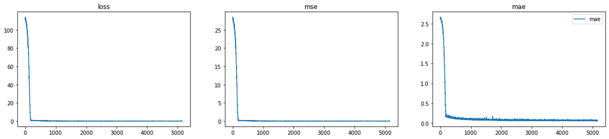

```
Train Loss: 0.026002608239650726
Train Mean square error: 0.00650
Train Mean absolute error: 0.03739
val results:
Mean square error: 0.02678
Mean absolute error: 0.06206
```

```python
class SalaryPredictorAttn(nn.Module):
    def __init__(self, n_tokens=len(tokens), n_cat_features=len(categorical_vectorizer.vocabulary_), hid_size=8):
      super().__init__()
      self.hid_size = hid_size
      self.embedder = nn.Embedding(n_tokens, hid_size)
      self.title_encoder = nn.Sequential(
          nn.Conv1d(hid_size, hid_size, kernel_size=2),
          nn.BatchNorm1d(hid_size),
          nn.Dropout(p=0.25),
          nn.ReLU()
      )
      self.description_encoder = nn.Sequential(
          nn.Conv1d(hid_size, hid_size, kernel_size=2),
          nn.BatchNorm1d(hid_size),
          nn.Dropout(p=0.25),
          nn.ReLU()
      )
      self.maxpool = nn.AdaptiveMaxPool1d(output_size=1)
      self.categorical_encoder = nn.Sequential(
          nn.Linear(n_cat_features, hid_size * 2),
          nn.ReLU(),
          nn.Linear(hid_size * 2, hid_size * 2),
          nn.ReLU()
      )
      self.prefinal_predictor = nn.Sequential(
          nn.Linear(hid_size * 4, hid_size),
          nn.ReLU()
      )
      self.final_predictor = nn.Sequential(
          nn.Linear(hid_size, 1)
      )


    def forward(self, batch):
      pooling = SelfAttentivePooling(self.hid_size)

      title_embeddings = self.embedder(batch['Title']).permute(0, 2, 1)
      title_features = self.title_encoder(title_embeddings)
      out_title = pooling(title_features.cpu()).cuda()

      description_embeddings = self.embedder(batch['FullDescription']).permute(0, 2, 1)
      description_features = self.description_encoder(description_embeddings)
      out_descr = pooling(description_features.cpu()).cuda()

      categorical_features = self.categorical_encoder(batch['Categorical'])

      features = torch.cat(
          [out_title, out_descr, categorical_features], dim=1)

      result = self.prefinal_predictor(features)

      return self.final_predictor(result).squeeze()

model = SalaryPredictorAttn().to(DEVICE)
model_attn, model_attn_plot = train_model(model)
```

По результатам всех экспериментов можно сказать, что лучшей моделью на train data стала модель LSTM (mse - 0.00345, mae - 0.02665), но на валидационных результаты были хуже, чем у некоторых других моделей.

Лучше всего на валидационных себя показали:

- Нейронная сеть с average pooling и параметром groups, равным 2: mse - 0.02528, mae - 0.0607
- Нейронная сеть с attentive pooling: mse - 0.02678, mae - 0.06206